# Kalshi Analysis 2025 (Updated June)

Author

Benjamin Sherman

## Introduction

**bes57.github.io/MLWebsite fans rejoice!** All one of you. (Hi Benny in the future!) Another month has passed, and thus another update to my trading journal. Honestly, I’m (pleasantly) surprised that I remembered to write again. So, here we go: Trading Journal Entry 2: Electric Boogaloo.

## Basic Statistics

#### *View below code to see library loading*

```r
#install.packages("kableExtra")
suppressPackageStartupMessages(library(tidymodels))
tidymodels_prefer()
suppressPackageStartupMessages(library(tidyverse))
library(shiny)
library(plotly)
library(forcats)
library(lubridate)
library(kableExtra)
library(glue)
library(rUM)
library(rio)
library(table1)
library(knitr)
library(gt)
library(broom)
library(stringr)
library(conflicted)
library(RColorBrewer)
conflicted::conflicts_prefer(plotly::layout)
[conflicted] Will prefer plotly::layout over any other package.
```

#### *View below code to see dataset loading/cleaning*

```r
clean_dollar <- function(x) {
  x <- gsub("[^0-9.-]", "", x)
  as.numeric(x)
}

Kalshi25June <- read.csv("~/Downloads/Benny_Website/Kalshi/Kalshi25June.csv", stringsAsFactors = FALSE)

Kalshi25June$Created_Clean <- gsub(" at ", " ", Kalshi25June$Created)
Kalshi25June$Created_Clean <- gsub(" EST", "", Kalshi25June$Created_Clean)
Kalshi25June$Created_Parsed <- parse_date_time(Kalshi25June$Created_Clean, orders = "b d, Y I:Mp")

Kalshi25June$Month <- format(Kalshi25June$Created_Parsed, "%B")
Kalshi25June$DayOfWeek <- weekdays(Kalshi25June$Created_Parsed)
Kalshi25June$Hour <- hour(Kalshi25June$Created_Parsed)

Kalshi25June <- Kalshi25June |> select(-Created)

Kalshi25June$Realized_Profit_Clean   <- clean_dollar(Kalshi25June$Realized_Profit)
Kalshi25June$Realized_Revenue_Clean <- clean_dollar(Kalshi25June$Realized_Revenue)
Kalshi25June$Realized_Cost_Clean    <- clean_dollar(Kalshi25June$Realized_Cost)
Kalshi25June$Fees_Clean             <- clean_dollar(Kalshi25June$Fees)
Kalshi25June$Contracts              <- as.numeric(Kalshi25June$Contracts)

baseball_df <- Kalshi25June %>%
  filter(str_starts(Ticker, "KXMLBGAME")) %>%
  filter(!is.na(Realized_Profit_Clean), Contracts > 0) %>%
  mutate(GameID = str_replace(Ticker, "-[^-]+$", ""))

baseball_summary <- baseball_df %>%
  group_by(GameID) %>%
  summarise(
    Realized_Profit_Clean   = sum(Realized_Profit_Clean, na.rm = TRUE),
    Realized_Revenue_Clean  = sum(Realized_Revenue_Clean, na.rm = TRUE),
    Realized_Cost_Clean     = sum(Realized_Cost_Clean, na.rm = TRUE),
    Fees_Clean              = sum(Fees_Clean, na.rm = TRUE),
    Contracts               = sum(Contracts, na.rm = TRUE),
    Created_Parsed          = min(Created_Parsed, na.rm = TRUE),
    .groups = "drop"
  )

baseball_metadata <- baseball_df %>%
  group_by(GameID) %>%
  slice(1) %>%
  ungroup() %>%
  select(-Realized_Profit_Clean, -Realized_Revenue_Clean, -Realized_Cost_Clean, -Fees_Clean, -Contracts, -Created_Parsed)

baseball_collapsed <- left_join(baseball_summary, baseball_metadata, by = "GameID") %>%
  mutate(Ticker = GameID) %>%
  select(-GameID)

non_baseball_df <- Kalshi25June %>%
  filter(!str_starts(Ticker, "KXMLBGAME"))

Kalshi25June_arb <- bind_rows(non_baseball_df, baseball_collapsed)

# WNBA Arbitrages
womensbball <- Kalshi25June_arb %>%
  filter(str_starts(Ticker, "KXWNBAGAME")) %>%
  filter(!is.na(Realized_Profit_Clean)) %>%
  mutate(
    GameID = str_replace(Ticker, "-[^-]+$", ""),
    Contracts = as.numeric(Contracts)
  )

womensbball_collapsed <- womensbball %>%
  group_by(GameID) %>%
  summarise(
    Ticker                 = first(GameID),
    Realized_Profit_Clean = sum(Realized_Profit_Clean, na.rm = TRUE),
    Realized_Revenue_Clean = sum(Realized_Revenue_Clean, na.rm = TRUE),
    Realized_Cost_Clean    = sum(Realized_Cost_Clean, na.rm = TRUE),
    Fees_Clean             = sum(Fees_Clean, na.rm = TRUE),
    Contracts              = sum(Contracts, na.rm = TRUE),
    Created_Parsed         = min(Created_Parsed, na.rm = TRUE),
    .groups = "drop"
  )

non_womensbball <- Kalshi25June_arb %>%
  filter(!str_starts(Ticker, "KXWNBAGAME"))

Kalshi25June_arb <- bind_rows(non_womensbball, womensbball_collapsed) %>%
  arrange(desc(Created_Parsed))

# UFC Arbitrages
ufc <- Kalshi25June_arb %>%
  filter(str_starts(Ticker, "KXUFCFIGHT")) %>%
  filter(!is.na(Realized_Profit_Clean)) %>%
  mutate(
    GameID = str_replace(Ticker, "-[^-]+$", ""),
    Contracts = as.numeric(Contracts)
  )

ufc_collapsed <- ufc %>%
  group_by(GameID) %>%
  summarise(
    Ticker                 = first(GameID),
    Realized_Profit_Clean = sum(Realized_Profit_Clean, na.rm = TRUE),
    Realized_Revenue_Clean = sum(Realized_Revenue_Clean, na.rm = TRUE),
    Realized_Cost_Clean    = sum(Realized_Cost_Clean, na.rm = TRUE),
    Fees_Clean             = sum(Fees_Clean, na.rm = TRUE),
    Contracts              = sum(Contracts, na.rm = TRUE),
    Created_Parsed         = min(Created_Parsed, na.rm = TRUE),
    .groups = "drop"
  )

non_ufc <- Kalshi25June_arb %>%
  filter(!str_starts(Ticker, "KXUFCFIGHT"))

Kalshi25June_arb <- bind_rows(non_ufc, ufc_collapsed) %>%
  arrange(desc(Created_Parsed))

# NCAA MBB Arbitrages
ncaa_mbb <- Kalshi25June_arb %>%
  filter(str_starts(Ticker, "KXNCAAMBACHAMP")) %>%
  filter(!is.na(Realized_Profit_Clean)) %>%
  mutate(
    GameID = str_replace(Ticker, "-[^-]+$", ""),
    Contracts = as.numeric(Contracts)
  )

ncaa_mbb_collapsed <- ncaa_mbb %>%
  group_by(GameID) %>%
  summarise(
    Ticker                 = first(GameID),
    Realized_Profit_Clean = sum(Realized_Profit_Clean, na.rm = TRUE),
    Realized_Revenue_Clean = sum(Realized_Revenue_Clean, na.rm = TRUE),
    Realized_Cost_Clean    = sum(Realized_Cost_Clean, na.rm = TRUE),
    Fees_Clean             = sum(Fees_Clean, na.rm = TRUE),
    Contracts              = sum(Contracts, na.rm = TRUE),
    Created_Parsed         = min(Created_Parsed, na.rm = TRUE),
    .groups = "drop"
  )

non_ncaa_mbb <- Kalshi25June_arb %>%
  filter(!str_starts(Ticker, "KXNCAAMBACHAMP"))

Kalshi25June_arb <- bind_rows(non_ncaa_mbb, ncaa_mbb_collapsed) %>%
  arrange(desc(Created_Parsed))

# Categorize Kalshi25June_arb markets into logical buckets
Kalshi25June_arb <- Kalshi25June_arb %>%
  mutate(
    Category = case_when(
      str_detect(Ticker, regex("^(KXMLBGAME|MLBGAME)", ignore_case = TRUE))        ~ "Baseball",
      str_detect(Ticker, regex("^(KXNBAGAME|KXNBASERIES|KXNBA|KXNBADRAFT)", ignore_case = TRUE))   ~ "Basketball",
      str_detect(Ticker, regex("^(KXWNBAGAME|WNBA)", ignore_case = TRUE))         ~ "Women's Basketball",
      str_detect(Ticker, regex("^(KXNHLGAME|KXNHL)", ignore_case = TRUE))         ~ "Hockey",
      str_detect(Ticker, regex("^(UFC|KXUFC)", ignore_case = TRUE))                       ~ "UFC",
      str_detect(Ticker, regex("(MARMAD|NCAAMB)", ignore_case = TRUE))            ~ "College Basketball",
      str_detect(Ticker, regex("(WMARMAD|NCAAWB)", ignore_case = TRUE))           ~ "Women’s College Basketball",
      str_detect(Ticker, regex("(KXMASTERS|PGA(TOUR)?|USOPEN|LIVTOUR)", ignore_case = TRUE)) ~ "Golf",
      str_detect(Ticker, regex("(WIMBLEDON|FOMENSINGLES|FOWOMENSINGLES)", ignore_case = TRUE)) ~ "Tennis",
      str_detect(Ticker, regex("(BITCOIN|BTC)", ignore_case = TRUE))              ~ "Crypto",
      str_detect(Ticker, regex("(MENTION|KXTRUMP)", ignore_case = TRUE))                    ~ "Mention Markets",
      str_detect(Ticker, regex("(VALORANT|VCT|AUSTINMAJOR|CS2?|ESPORT)", ignore_case = TRUE)) ~ "Esports",
      str_detect(Ticker, regex("^(KXMAYOR)", ignore_case = TRUE))        ~ "Politics",
      str_detect(Ticker, regex("^(KXAPP)", ignore_case = TRUE))        ~ "App Ranking",

      TRUE ~ "Other"
    )
  )
```

The benefit of this being my second entry is that I can copy over some of the dataset manipulation/cleaning from my first entry. Not only that, but I can improve on it. For example, in my arbitrage code, I only combined the values for `Realized_Profit_Clean` while all of the other values (e.g. `Realized_Revenue_Clean`, `Realized_Cost_Clean`, `Fees_Clean`) were turned into zeroes. This is accounted for in the revamped code above. Secondly, I added in a new variable to sort my trading markets into categories (for example, Baketball, Golf, Mention Markets, etc.) This will open some new avenues for qualitative analysis later on.

Now, let’s start with the most straightforward but important calculation.

#### Firstly, my profit thus far in 2025:

```r
total_realized_profit <- sum(Kalshi25June_arb$Realized_Profit_Clean, na.rm = TRUE)


data.frame(Total_Realized_Profit = dollar(total_realized_profit)) |>
  kable(caption = "", align = "c") |>
  kable_styling(full_width = FALSE)
```

| Total_Realized_Profit |
| --- |
| $7,804.01 |

Two notably good things:

1. The number is still positive
2. The number is getting bigger (*$4,819 in May’s update -> $7,804 in June’s update*)

#### Now, let’s look at my biggest losses and wins in 2025. Has anything changed compared to May’s entry?

```r
top_wins <- Kalshi25June_arb %>%
  arrange(desc(Realized_Profit_Clean)) %>%
  slice_head(n = 5)

top_losses <- Kalshi25June_arb %>%
  arrange(Realized_Profit_Clean) %>%
  slice_head(n = 5)

biggest_outliers <- bind_rows(top_wins, top_losses)

biggest_outliers %>%
  select(Date = Created_Parsed, Profit = Realized_Profit_Clean, Ticker) %>%
  mutate(
    Date = format(Date, "%b %d, %Y %I:%M %p"),
    Profit = dollar(Profit)
  ) %>%
  kable(caption = "Top 5 Gains and Losses Across All Trades (2025)", align = "c") %>%
  kable_styling(full_width = FALSE, bootstrap_options = c("striped", "hover", "condensed"))
```

Top 5 Gains and Losses Across All Trades (2025)

| Date | Profit | Ticker |
| --- | --- | --- |
| Feb 02, 2025 05:46 PM | $268.80 | KXGRAMBCS-67-TA |
| Mar 21, 2025 09:32 PM | $181.14 | KXPRESLEAVESK-25-APR |
| Apr 07, 2025 10:11 PM | $165.20 | KXMARMAD-25-HOU |
| Apr 25, 2025 12:40 AM | $150.00 | KXNBAGAME-25APR24OKCMEM-OKC |
| Jun 21, 2025 05:55 PM | $136.15 | KXUFCFIGHT-25JUN21HILROU |
| Apr 04, 2025 11:52 AM | -$286.66 | KXPRESLEAVESK-25-MAY |
| Mar 23, 2025 11:19 AM | -$181.83 | KXAPPRANKFREE-25MAR23-NCA |
| May 21, 2025 09:23 PM | -$172.18 | KXTRUMPMENTION-25MAY21-REF |
| May 21, 2025 02:58 PM | -$121.52 | KXMLBGAME-25MAY21BALMIL |
| Jul 02, 2025 08:36 PM | -$107.39 | KXMLBGAME-25JUL02CINBOS |

Two new entries: my fifth-largest loss and my fifth-largest profit. That new entry in the profit list (KXUFCFIGHT-25JUN21HILROU) is notable, mainly because the UFC market is a new category I’ve experimented with this month. My trading in June was largely defined by developing consistent, profitable strategy on recurring markets (which will be discussed later) but the UFC market is a complete departure from that trend.

UFC markets are not consistently occurring and they’re extremely inefficient/bizarre. More specifically, they’re bizarre in how they behave relative to other sports markets. How? Well, sports markets tend to be heavily botted. Large trading firms create hyper-efficient algorithms that put forth tens of thousands of shares in a very tight spread around their projected probability. This forces traders (like myself) to try to find profit in that tight margin, meaning higher risk and smaller profits. If you’re not careful in these markets, the firms will take your bids and your money as well. However, the UFC markets offer the question: how do you calculate the probability of winning for a fighter mid-fight? The short answer is: you can’t. At least not well.

To understand why that is, it’s easier to understand first why firms are able to make such tight spreads on (for example) basketball markets mid-game. This is because:

1. they have a number of objective, constantly updating, and important variables they can punch into their formula.
2. the plethora of (impactful) variables creates extremely precise projections.

In the UFC, neither of these conditions are met. While, in basketball, you can look at things like `scoring totals`, `shooting efficiency`, `fouls to give`, and so forth, the UFC offers very few variables. I mean, really, what can you track? The only real answer is a variable like `punches landed` or `times knocked down`, but that’s little information to work with. Furthermore, something like `punches landed` is flawed because some hits are harder than others, some hits aren’t even clear as to whether they landed, etc. Meanwhile, something like `point differential` in basketball is an objective reality.

The end result is that firms have less information to create live projections with. Even if they do create spreads, the spreads have to be *very* wide to account for their projections uncertainty due to the low-information nature of the sport.

How does this come back to me? Honestly, I just think this is an interesting phenomenon in the world of sports markets. However, this background gives context as to how I was able to make that much money in a single market. Recall when I previously described how trading firms create tight spreads that stifle traders with their unbeatable efficiency and up-to-date information? Well, the opposite happens in the UFC fights. With little to no botted activity whatsoever, there are large spreads with high liquidity, which births great opportunities to quickly build arbitrages with high volume. That allllllll comes back to me making $136 on a fight that lasted 25 minutes.

It’s important to note, though, that the nature of UFC fights being far and few between means that this is neither a large nor consistent source of profit.

## Consistency

Well, market analysis aside, I’d like to transition by coming back to a previously written sentiment of mine: May was about developing my strategies while June was more so about consistent application of the same techniques on the same markets (albeit some small, insignificant tweaks.) Well, let’s check my consistency!

#### Observe my trading calendar for June:

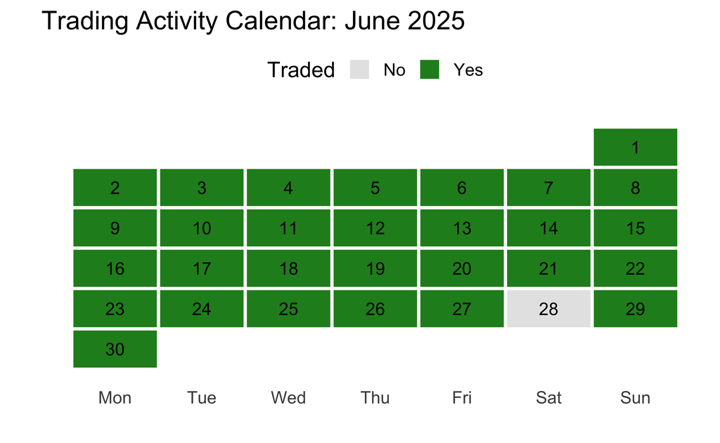

```r
june_trades <- Kalshi25June_arb %>%
  filter(!is.na(Created_Parsed)) %>%
  filter(month(Created_Parsed) == 6, year(Created_Parsed) == 2025) %>%
  mutate(Trade_Date = as.Date(Created_Parsed)) %>%
  distinct(Trade_Date)

june_days <- tibble(Date = seq(as.Date("2025-06-01"), as.Date("2025-06-30"), by = "day")) %>%
  mutate(
    Weekday = wday(Date, week_start = 1),
    Week = as.integer(format(Date - days(1), "%U")) - min(as.integer(format(Date - days(1), "%U"))) + 1,
    Traded = if_else(Date %in% june_trades$Trade_Date, TRUE, FALSE)
  )

ggplot(june_days, aes(x = Weekday, y = -Week)) +
  geom_tile(aes(fill = Traded), color = "white", linewidth = 1) +
  geom_text(aes(label = day(Date)), color = "black", size = 4) +
  scale_x_continuous(breaks = 1:7, labels = c("Mon", "Tue", "Wed", "Thu", "Fri", "Sat", "Sun")) +
  scale_fill_manual(values = c("TRUE" = "forestgreen", "FALSE" = "gray90"), labels = c("No", "Yes")) +
  labs(
    title = "Trading Activity Calendar: June 2025",
    x = "", y = "",
    fill = "Traded"
  ) +
  theme_minimal(base_size = 14) +
  theme(
    panel.grid = element_blank(),
    axis.text.y = element_blank(),
    axis.ticks = element_blank(),
    legend.position = "top"
  )
```

Well, this proves my consistency time-wise in June.

#### How about my consistency market-wise?

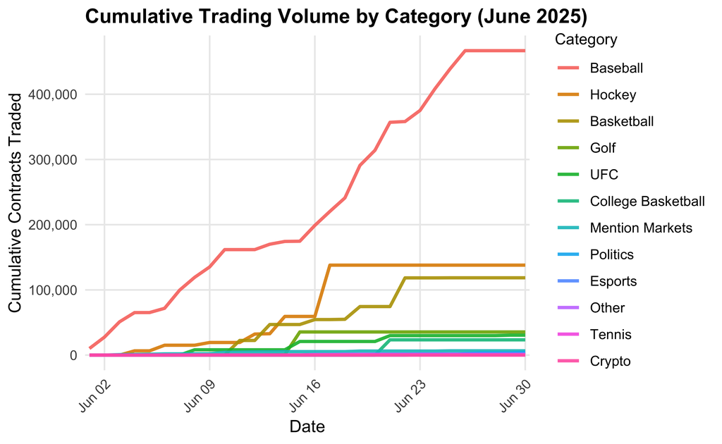

```r
Kalshi25June_arb <- Kalshi25June_arb %>%
  mutate(Trade_Date = as.Date(Created_Parsed))

june_data <- Kalshi25June_arb %>%
  filter(month(Trade_Date) == 6, year(Trade_Date) == 2025)

daily_summary <- june_data %>%
  group_by(Trade_Date, Category) %>%
  summarise(Daily_Contracts = sum(Contracts, na.rm = TRUE), .groups = "drop")

categories <- unique(daily_summary$Category)
june_dates <- seq(as.Date("2025-06-01"), as.Date("2025-06-30"), by = "day")

plot_data <- expand.grid(Trade_Date = june_dates, Category = categories) %>%
  left_join(daily_summary, by = c("Trade_Date", "Category")) %>%
  mutate(Daily_Contracts = replace_na(Daily_Contracts, 0)) %>%
  arrange(Category, Trade_Date) %>%
  group_by(Category) %>%
  mutate(Cumulative_Contracts = cumsum(Daily_Contracts)) %>%
  ungroup()

ordered_cats <- plot_data %>%
  group_by(Category) %>%
  summarise(Total = max(Cumulative_Contracts)) %>%
  arrange(desc(Total)) %>%
  pull(Category)

plot_data <- plot_data %>%
  mutate(Category = fct_relevel(Category, ordered_cats))

ggplot(plot_data, aes(x = Trade_Date, y = Cumulative_Contracts, color = Category)) +
  geom_line(size = 1, alpha = 0.9) +
  scale_x_date(
    date_breaks = "1 week",
    date_labels = "%b %d",
    expand = expansion(mult = c(0.01, 0.01))
  ) +
  scale_y_continuous(labels = scales::comma) +  # Moved outside of theme()
  labs(
    title = "Cumulative Trading Volume by Category (June 2025)",
    x = "Date",
    y = "Cumulative Contracts Traded",
    color = "Category"
  ) +
  theme_minimal(base_size = 11) +
  theme(
    axis.text.x = element_text(angle = 45, hjust = 1),
    legend.position = "right",
    legend.text = element_text(size = 9),
    legend.title = element_text(size = 10),
    plot.title = element_text(face = "bold", size = 13),
    panel.grid.minor = element_blank()
  )
```

This looks about right; there’s a consistent rate at which I’m trading on the baseball market, with some dabbling in other markets from time to time. This isn’t just a natural phenomenon, but it’s an intended result. My end goal was always to have some long-term edge that is consistent and reproducible, and after some expirimentation in May, it seems I’ve found that in baseball markets. Why do I want replicable consistency in my trading?

1. Having alpha in a daily market as opposed to sporadic, temporary markets (mention markets, march madness markets, etc.) offers more consistent flow of money with long-term value.
2. It’s easier to refine my strategy. With a daily market, I have a larger sample size to confirm that my strategy is profitable, experiment with different tweaks, and maximize profitability. Unpredictable markets are harder to prepare for and predict.
3. *(This is a less of a main point and more of a side consideration.)* If I’m able to refine my strategy and be confident that the market will exist each day and behave consistently, I could eventually code a bot to automate my trading process and create passive income. This is wishful thinking, though.

I realize that, as I’m writing this, I’m getting ahead of myself by constantly saying I’ve found “edge” and “profitability” with the baseball markets. All I’ve proven with the above graph is that I’m consistently trading on the baseball market, not that I’m consistently making money. To put doubt to rest, let’s be certain that I’m even making money, let alone whether I’m profitable long term.

#### Below is a graph of my profit over time for baseball markets in June

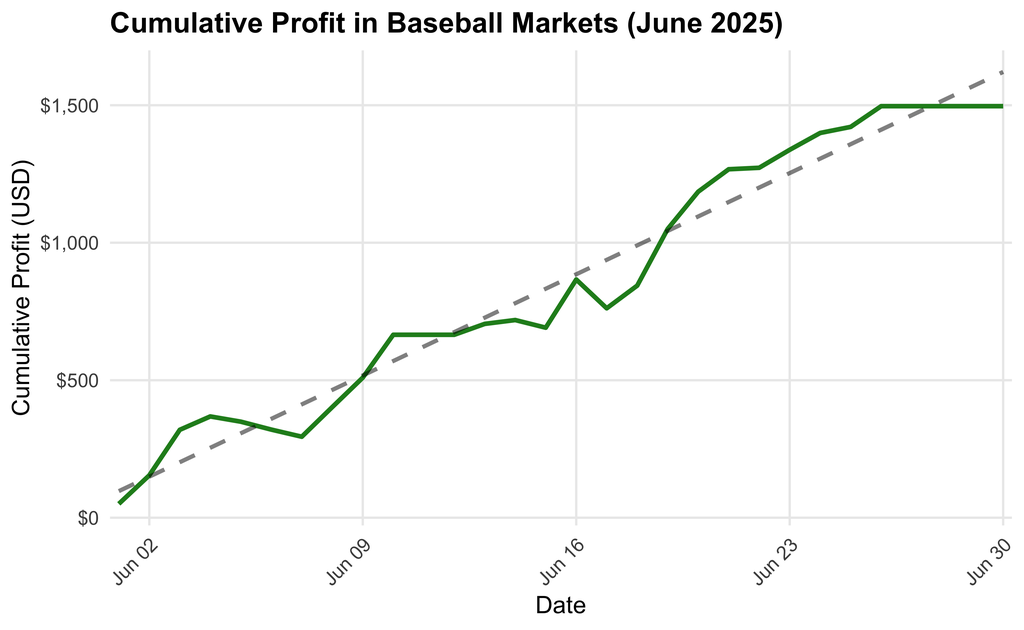

```r
baseball_june_plot <- Kalshi25June_arb %>%
  filter(Category == "Baseball") %>%
  filter(month(Created_Parsed) == 6, year(Created_Parsed) == 2025) %>%
  mutate(Trade_Date = as.Date(Created_Parsed)) %>%
  group_by(Trade_Date) %>%
  summarise(Daily_Profit = sum(Realized_Profit_Clean, na.rm = TRUE), .groups = "drop") %>%
  complete(Trade_Date = seq(as.Date("2025-06-01"), as.Date("2025-06-30"), by = "day"),
           fill = list(Daily_Profit = 0)) %>%
  arrange(Trade_Date) %>%
  mutate(Cumulative_Profit = cumsum(Daily_Profit))

lm_model <- lm(Cumulative_Profit ~ as.numeric(Trade_Date), data = baseball_june_plot)

baseball_june_plot <- baseball_june_plot %>%
  mutate(LM_Pred = predict(lm_model))

ggplot(baseball_june_plot, aes(x = Trade_Date, y = Cumulative_Profit)) +
  geom_line(color = "forestgreen", size = 1) +
  geom_line(aes(y = LM_Pred), color = "black", linetype = "dashed", size = 0.9, alpha = 0.5) +
  scale_x_date(
    date_breaks = "1 week",
    date_labels = "%b %d",
    expand = expansion(mult = c(0.01, 0.01))
  ) +
  scale_y_continuous(labels = scales::dollar) +
  labs(
    title = "Cumulative Profit in Baseball Markets (June 2025)",
    x = "Date",
    y = "Cumulative Profit (USD)"
  ) +
  theme_minimal(base_size = 11) +
  theme(
    axis.text.x = element_text(angle = 45, hjust = 1),
    plot.title = element_text(face = "bold", size = 13),
    panel.grid.minor = element_blank()
  )
```

There are some dips up and down, but given my high volume of trading and the consistent, upward linear trend, I feel affirmed in my assumption that I’ve found consistent edge in the baseball markets. This is what I’m most excited about in my trading during June. There looks to be a means of consistent profit over the next months (which will hopefully be confirmed in my next journal entry.)

Now, as much as I’d like to write *“my profit went up and I traded a lot, so I must be profitable”* and leave it at that, it would be good to confirm this assumption of mine. A graph by itself can’t rule out the possibility that random variance is masking deeper risk. For the sake of statistics, I’ll perform a t-test and a Wilcoxon test to confirm whether I can be confident that I’ve actually been profitable, or that I’m just lucky.

## t-test and Wilcoxon test

```r
baseball_profits_trade <- Kalshi25June_arb %>%
  filter(Category == "Baseball", !is.na(Realized_Profit_Clean)) %>%
  pull(Realized_Profit_Clean)

baseball_profits_game <- baseball_collapsed$Realized_Profit_Clean

t_test_game   <- t.test(baseball_profits_game,  alternative = "greater")
wilcox_game   <- wilcox.test(baseball_profits_game,  alternative = "greater")

format_test <- function(test_obj, test_name, est = NA, ci_low = NA, ci_high = NA) {
  tibble(
    Test = test_name,
    Estimate = est,
    Statistic = test_obj$statistic,
    `P-value` = formatC(test_obj$p.value, format = "e", digits = 3),
    `CI Lower` = ci_low,
    `CI Upper` = ci_high
  )
}

test_results <- bind_rows(
  format_test(t_test_game,   "T-test (Per Game)",    est = t_test_game$estimate,   ci_low = t_test_game$conf.int[1],  ci_high = t_test_game$conf.int[2]),
  format_test(wilcox_game,   "Wilcoxon (Per Game)",  est = median(baseball_profits_game))
)

test_results %>%
  kable(caption = "Hypothesis Test Results: Profitability in Baseball Markets", align = "c") %>%
  kable_styling(full_width = FALSE, bootstrap_options = c("striped", "hover", "condensed"))
```

Hypothesis Test Results: Profitability in Baseball Markets

| Test | Estimate | Statistic | P-value | CI Lower | CI Upper |
| --- | --- | --- | --- | --- | --- |
| T-test (Per Game) | 9.71 | 5.23 | 1.770e-07 | 6.65 | Inf |
| Wilcoxon (Per Game) | 5.32 | 23989.00 | 2.040e-13 | NA | NA |

#### Histogram to check for normality

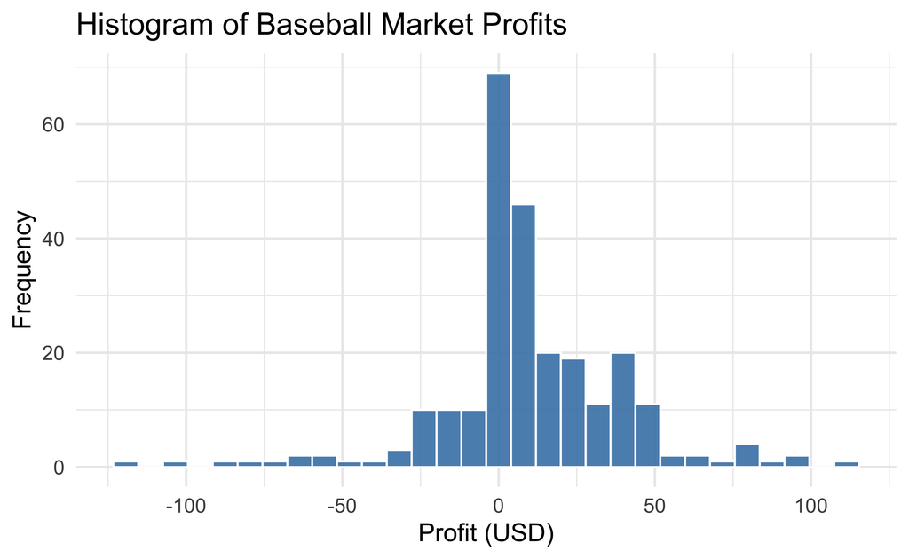

```r
baseball_profits <- Kalshi25June_arb %>%
  filter(Category == "Baseball", !is.na(Realized_Profit_Clean)) %>%
  pull(Realized_Profit_Clean)

ggplot(data.frame(Profit = baseball_profits), aes(x = Profit)) +
  geom_histogram(bins = 30, fill = "steelblue", color = "white", alpha = 0.9) +
  labs(
    title = "Histogram of Baseball Market Profits",
    x = "Profit (USD)",
    y = "Frequency"
  ) +
  theme_minimal(base_size = 13)
```

## Conclusion (with a twist)

As a fun way of ending my journal entry, I’ve abandoned the analysis and narrative on “trends”, “averages”, and “probabilities.” Whole buncha baloney. Instead, I’m leaving you, dear reader, with a tool to do your own perusing. Below is a calendar-based plot: use the slider at the bottom to select any day in June 2025, and you’ll see a diverging bar chart of my profits across each market category for that day. I’ve found that sliding through days is an easy way to understand what a typical day (trading-wise) looked like for me in June 2025. You can even spot some trends.

Enjoy!

```r
june_daily_cat <- Kalshi25June_arb %>%
  filter(month(Created_Parsed) == 6, year(Created_Parsed) == 2025) %>%
  mutate(Trade_Date = as.Date(Created_Parsed)) %>%
  filter(Category != "Crypto") %>%
  group_by(Trade_Date, Category) %>%
  summarise(Day_Profit = sum(Realized_Profit_Clean, na.rm = TRUE), .groups = "drop")

all_dates      <- sort(unique(june_daily_cat$Trade_Date))
all_categories <- sort(unique(june_daily_cat$Category), decreasing = TRUE)

complete_grid <- expand.grid(Trade_Date = all_dates,
                             Category    = all_categories,
                             KEEP.OUT.ATTRS = FALSE)

june_daily_cat <- complete_grid %>%
  left_join(june_daily_cat, by = c("Trade_Date", "Category")) %>%
  mutate(
    Day_Profit = replace_na(Day_Profit, 0),
    Category   = factor(Category, levels = all_categories)
  )

p <- plot_ly()

# Add one trace per day
for (i in seq_along(all_dates)) {
  day_data <- june_daily_cat %>% filter(Trade_Date == all_dates[i])
  p <- add_bars(
    p,
    x       = ~Category,
    y       = ~Day_Profit,
    data    = day_data,
    name    = format(all_dates[i], "%b %d"),
    marker  = list(color = ifelse(day_data$Day_Profit >= 0, "forestgreen", "firebrick")),
    visible = i == 1
  )
}

# Slider steps
steps <- lapply(seq_along(all_dates), function(i) {
  list(
    method = "update",
    args   = list(list(visible = lapply(seq_along(all_dates), function(j) j == i)),
                  list(title = paste("Profit by Category –", format(all_dates[i], "%b %d, %Y")))),
    label  = format(all_dates[i], "%b %d")
  )
})

# Layout with slider
p <- layout(
  p,
  title  = paste("Profit by Category –", format(all_dates[1], "%b %d, %Y")),
  xaxis  = list(title = "Market Category"),
  yaxis  = list(title = "Profit (USD)", range = c(-250, 250)),
  sliders = list(list(
    active = 0,
    steps = steps,
    x = 0.1,
    xanchor = "left",
    y = -0.2,
    yanchor = "top"
  ))
)

p
```

[interactive chart not shown]